## Assignment 9

#### Due Friday, April 14, 11:59 PM CT

### Preliminaries

- Directories
  - COURSE/homework/
  - COURSE/homework/hw09/
  - COURSE/data/
  - COURSE/scripts/
- Files
  - COURSE/homework/hw09/hw09.Rmd
  - COURSE/data/chimpanzees.csv
  - COURSE/scripts/viridis.R
  - COURSE/scripts/ggprob.R

### Data

- The data are in the file `chimpanzee.csv`.
- These data are artificial, but created to match details from a 2011 PNAS paper on chimpanzee prosocial choice.
- See the [Course Notes and Case Studies Chapter 18](https://bookdown.org/bret_larget/stat-240-case-studies/chimpanzees-and-prosocial-choice.html) for background on the data.

### Aims

- Practice inference on proportions

## Problems

1. This problem uses the chimpanzee prosocial experiment data we have been using in lecture. For this problem, we will:
- Consider only those trials with a partner.
- Make an assumption that there is a universal $p_{\text{partner}}$ representing the probability any chimpanzee would make a prosocial choice in a single trial under the experimental conditions we have been examining.
- Assume that all trials are independent.

Do the following:

- Read in the `chimpanzee.csv` data file.
- Create a summary table with:
  - one row for all trials with a partner and one row for all trials without a partner;
  - a column `prosocial` with the combined number of prosocial choices made (separate values for with and without a partner);
  - a column `selfish` for the number of selfish choices made;
  - a column `n` with the combined number of trials (values should be 610 and 180);
  - a column `p_prosocial` with the proportion of prosocial choices made.
- Print the entire table

```r
ch = read.csv("../../data/chimpanzee.csv")

ch["partner_exists"] = ch$partner != "none"

ch_s = ch %>%
  group_by(partner_exists) %>%
  summarize(prosocial = sum(prosocial), selfish = sum(selfish), n = prosocial + selfish, p_prosocial = prosocial / n)

ch_s %>% print()
```

```
## # A tibble: 2 × 5
##   partner_exists prosocial selfish     n p_prosocial
##   <lgl>              <int>   <int> <int>       <dbl>
## 1 FALSE                 83      97   180       0.461
## 2 TRUE                 359     251   610       0.589
```

2. Define $p_1 = p_{\text{partner}}$ and $p_2 = p_{\text{no partner}}$ to be the long-run probabilities that chimpanzees make the prosocial choices with and without a partner, respectively, in the experimental conditions. (*You can decide which subscripts to use*.) Note that these parameter definitions implicitly assume that all trials are independent and that the identities of the chimpanzees and their partners do not affect the prosocial trial probabilities. These assumptions could and should be examined, but complete these problems as if the assumptions are accurate.
- Write a statistical model for the data, $X_1$ and $X_2$, the number of pro-social choices under the two conditions. (It may be helpful to copy and edit LaTeX syntax from the lecture notes if you want to make the knitted document look pretty, but plain text is also fine.)
- X1 ∣ p1 ∼ Binomial(610,p1)
- X2 ∣ p2 ∼ Binomial(180,p2)
- Use the data summary in Problem 1 to construct a 95% confidence interval for $p_{\text{partner}} - p_{\text{no partner}}$ (or $p_1 - p_2$), using the Agresti-Coffe method for confidence intervals for differences in proportions.

```r
n1 = 610
n2 = 180
n1_ex = n1 + 2
n2_ex= n2 + 2

p1_ex = ((0.589 * n1) + 1)/ (n1_ex + 2)
p2_ex = ((0.461 * n2) + 1)/ (n2_ex + 2)

se = sqrt((p1_ex*(1-p1_ex))/n1_ex + (p2_ex*(1-p2_ex))/n2_ex)
error = 1.96 * se

lower = (p1_ex - p2_ex) - error
upper = (p1_ex - p2_ex) + error
```

```r
p11 = dbinom(359, 610, 0.5)
tibble(
     x = 0:610,
     prob = dbinom(x, 610, 0.5)) %>%
     filter(near(prob, p11))
```

```
## # A tibble: 2 × 2
##       x       prob
##   <int>      <dbl>
## 1   251 0.00000220
## 2   359 0.00000220
```

```r
pbinom(251, 610, 0.5) + (1 - pbinom(358, 610, 0.5))
```

```
## [1] 1.405895e-05
```

the p-value is very small . Thus the null hypothesis is likely false. There is strong evidence (p=1.405895e-05, two-sided binomial test) that the chimpanzee in this experiment will make the aberrant and wierd choices.

4. For the previous problem, create a graph that shows the sampling distribution of $X_1$ under the null hypothesis and indicates (with different colors and/or lines) how the p-value relates to the graph.

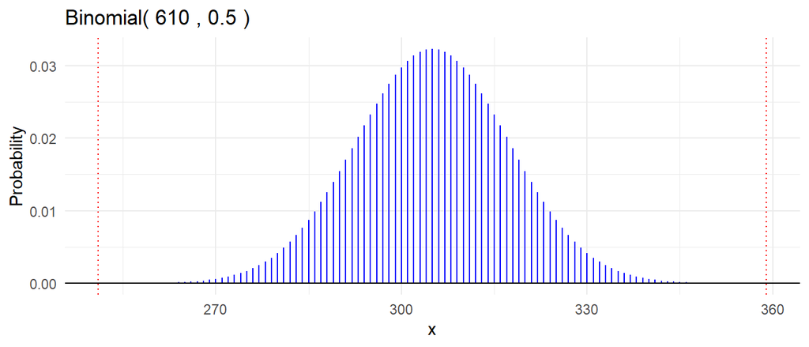

```r
gbinom(610, 0.5, scale=TRUE) +
  geom_vline(xintercept=c(359, 251), color="red",
             linetype="dotted")
```

```r
p111 = dbinom(83, 180, 0.5)
tibble(
     x = 0:180,
     prob1 = dbinom(x, 180, 0.5)) %>%
     filter(near(prob1, p_359))
```

[output not shown]

```r
(1 - pbinom(96, 180, 0.5))+pbinom(83, 180, 0.5)
```

```
## [1] 0.3325791
```

```r
p111
```

```
## [1] 0.03454022
```

6. The previous statistical inferences assume a binomial model for the observed number of prosocial choices for trials with and without a partner.

State one criticism where reality may differ from the assumptions, possibly leading to misleading conclusions. (What is an example of an assumption of the binomial model which, in the given context, is questionable?)

7. In a poll from the 2022 election for governor in Wisconsin, 326 out of 679 likely voters responded that they would vote for the incumbent Tony Evers. Using the Agresti-Coull method, find a 95% confidence interval for the proportion of likely voters in Wisconsin who voted vote for Tony Evers in the November 8 election.

```r
binom_se =  function(n1, p1){
  return ( sqrt( p1*(1-p1)/n1) )
}
binom_ci = function(e, se, conf=0.95){
  z = qnorm(1 - (1 - conf)/2)
  me = z * se
  ci = e+ c(-1,1)*me
  return(ci)
}

n_give = 679
p_give = (326 + 2) / (n + 4)
```

[output not shown]

```r
se_get = binom_se(n+4, p)
```

```
## Error in binom_se(n + 4, p): object 'p' not found
```

```r
ci_agresti = binom_ci(p, se_get)
```

```
## Error in binom_ci(p, se_get): object 'se_get' not found
```

```r
round(ci_agresti, 3)
```

```
## Error in eval(expr, envir, enclos): object 'ci_agresti' not found
```

8. In a psychological experiment, a reported psychic tries to guess the suit of the cards of a well-shuffled stack of cards which includes many decks shuffled together. You may assume that the suit of each card in order is equally likely to be any one of the four suits and that the suits of the cards are independent of each other.

In guesses of the suits of 100 cards, the psychic correctly guesses the suit 29 times. Conduct a formal hypothesis test to examine the evidence that the psychic can guess the suit of the cards more often than expected. State a model, declare a test statistic, state hypotheses, calculate a one-sided p-value, and report the results in the context of the problem following the format presented in lecture notes.

```r
p_ = dbinom(29, 100, 0.29)
tibble(
     x = 0:100,
     prob = dbinom(x, 100, 0.29)) %>%
     filter(near(prob, p_))
```

```
## # A tibble: 1 × 2
##       x   prob
##   <int>  <dbl>
## 1    29 0.0876
```

```r
1 - pbinom(28, 100, 0.29)
```

```
## [1] 0.537742
```